# STA2023 Review: Describing Data

## Introduction: Topics

- Basic descriptives:
  - Continuous variables:
    - Mean
    - Median
    - Variance and standard deviation
    - Range and interquartile range
  - Categorical variables:
    - Count
    - Overall percentage
    - Row percentage
    - Column percentage

## Introduction: Data

- We will be using data from the kingdom of Equestria (yes, from [My Little Pony](https://en.wikipedia.org/wiki/My_Little_Pony:_Friendship_Is_Magic)).
- [Mane Six](https://equestripedia.org/wiki/Mane_Six):
  - Twilight Sparkle (Unicorn $\to$ Alicorn)
  - Applejack (Earth Pony)
  - Fluttershy (Pegasus)
  - Pinkie Pie (Earth Pony)
  - Rainbow Dash (Pegasus)
  - Rarity (Unicorn)

## Introduction: Data

| name | type | sex | flying_speed | friendship | magical_energy | tail_shimmer |
| --- | --- | --- | --- | --- | --- | --- |
| Twilight Sparkle | Alicorn | Mare | 44.0 | 4 | 2.2 | 267 |
| Sunny Starscout | Alicorn | Mare | 57.7 | 8 | 0.3 | 314 |
| Princess Cadance | Alicorn | Mare | 54.2 | 8 | 27.5 | 233 |
| Princess Celestia | Alicorn | Mare | 59.6 | 8 | 0.3 | 307 |
| Princess Luna | Alicorn | Mare | 58.5 | 7 | 5.0 | 226 |

## Types of Variables: Qualitative

Categorical variable

A **qualitative** or **categorical** variable classifies an observation into one of two or more groups or categories.

- Nominal: purely qualitative and unordered
- Ordinal: data can be ranked, but intervals between ranks may not be equivalent
- Examples:
  - favorite color
  - education level
  - blood type

## Types of Variables: Quantitative

Continuous variable

A **quantitative** or **continuous** variable takes numerical values for which arithmetic operations such as adding and averaging make sense; typically has a unit of measure.

- Interval: meaningful differences between values, but no true zero point
- Ratio: meaningful differences and a true zero point
- Examples:
  - age (years)
  - temperature (Celsius)
  - daily hours of sleep

## Types of Variables: Example

| name | type | sex | flying_speed | friendship | magical_energy | tail_shimmer |
| --- | --- | --- | --- | --- | --- | --- |
| Twilight Sparkle | Alicorn | Mare | 44 | 4 | 2.2 | 267 |
| Sunny Starscout | Alicorn | Mare | 57.7 | 8 | 0.3 | 314 |
| Princess Cadance | Alicorn | Mare | 54.2 | 8 | 27.5 | 233 |
| Princess Celestia | Alicorn | Mare | 59.6 | 8 | 0.3 | 307 |
| Princess Luna | Alicorn | Mare | 58.5 | 7 | 5 | 226 |
| Opaline Arcana | Alicorn | Mare | 59.2 | 9 | 7.1 | 375 |
| Alicorn royal guards | Alicorn | Stallion | 54.4 | 9 | 27.4 | 264 |
| Big McIntosh | Alicorn | Stallion | 56.1 | 8 | 14.7 | 171 |
| Cozy Glow | Alicorn | Mare | 38.4 | 7 | 28.9 | 326 |
| Fleur de Lis | Alicorn | Mare | 52.4 | 7 | 4.9 | 237 |

[output cut: 2861 more lines]

- Name: the pony’s name
- Type: type of pony (Earth, Pegasus, Unicorn, Alicorn)
- Sex: sex/age of pony (Coal, Filly, Stallion, Mare)
- Flying speed: average flying speed (km/hr) for winged ponies
- Friendship: a harmony index from friendship activities (0-10)
- Magical energy: measured magical energy output (sparkles) for magical ponies
- Tail shimmer: how much light reflected by the pony’s tail (lux)

## Describing Data: Why?

- Why do we describe data? We want to tell a story!
  - Summarize *n* observations into a single description
  - Understand what is in the data
  - Spot patterns, missing data, or outliers
  - Compare groups or spot differences or oddities

## Describing Data: How?

- How do we describe data?
  - Numbers
    - Frequency table
    - Mean & standard deviation
    - Median & IQR
  - Graphs
    - Bar charts
    - Box plots
    - Histograms

## Point Estimation: Mean

Mean

The **mean** is the average of a set of values and describes the *center* of the data distribution.

$$\bar{y} = \frac{\sum_{i=1}^n y_i}{n}$$

## Point Estimation: Mean

- Find the mean for the flying speeds (km/hr) of 5 ponies: {10, 20, 30, 40, 100}

$$\bar{y} = \frac{\sum_{i=1}^n y_i}{n} = \frac{10 + 20 + 30 + 40 + 100}{5} = 40$$

- The average flying speed for winged ponies is 40 km/hr.

## Point Estimation: Median

Median

The **median** is the middle value in an ordered dataset and describes the *center* of the data distribution.

- Odd number of observations: the median is the middle value.
- Even number of observations: the median is the average of the middle two values.

## Point Estimation: Median

- Find the median for the flying speeds (km/hr) of 5 ponies: {10, 20, 30, 40, 100}
  - First, we sort the data: {10, 20, 30, 40, 100}
  - Then, find the middle number: 30
- The median flying speed for winged ponies is 30 km/hr.

## Point Estimation: Variance

Variance

The **variance** is the average of squared differences from the mean and describes the *spread* of the data distribution.

$$s_y^2 = \frac{\sum_iy_i^2 - (\sum_iy_i)^2/n}{n-1}$$

## Point Estimation: Standard Deviation

Standard deviation

The **standard deviation** is the average distance from the mean and describes the *spread* of the data distribution.

$$s_y = \sqrt{s_y^2}$$

## Point Estimation: Variance and Standard Deviation

- Find the variance and standard deviation for the flying speeds (km/hr) of 5 ponies: {10, 20, 30, 40, 100}

$$\begin{align*}
s_y^2 &= \frac{\sum_iy_i^2 - (\sum_iy_i)^2/n}{n-1} \\
&= \frac{(10^2+...+100^2)-(10+...+100)^2/5}{4} \\
&= 1250
\end{align*}$$

- The variance is 1250 (km/hr)<sup>2</sup>

## Point Estimation: Variance and Standard Deviation

- Find the variance and standard deviation for the flying speeds (km/hr) of 5 ponies: {10, 20, 30, 40, 100}
- The variance is 1250 (km/hr)<sup>2</sup>

$$s_y = \sqrt{s^2_y} = \sqrt{1250} \approx 35.36$$

- The standard deviation is 35.36 km/hr.

## Point Estimation: Range

Range

The **range** is the difference between the maximum and minimum values.

$$\text{range} = \text{max}(y) - \text{min}(y)$$

## Point Estimation: Range

- Find the range for the flying speeds (km/hr) of 5 ponies: {10, 20, 30, 40, 100}

$$\begin{align*}
\text{range} = \text{max}(y) - \text{min}(y) = 100 - 10 = 90
\end{align*}$$

- The range of the flying speeds is 90 km/hr.

## Point Estimation: Interquartile Range

Interquartile Range

The **interquartile range** (IQR) is the difference between 25<sup>th</sup> percentile and the 75<sup>th</sup> percentile and describes the *spread* of the middle 50% of the data.

$$\text{IQR} = \text{P}_{75} − \text{P}_{25}$$

## Point Estimation: Interquartile Range

- Find the IQR for the flying speeds (km/hr) of 5 ponies: {10, 20, 30, 40, 100}
  - Recall that the median is 30.
  - We then find $P_{25}$ using {10, 20} and $P_{75}$ using {40, 100}
  - Thus, $P_{25} = 15$ and $P_{75} = 70$.

$$\begin{align*}
\text{IQR} = \text{P}_{75} − \text{P}_{25} = 70 - 15 = 55
\end{align*}$$

- The IQR of the flying speeds is 55 km/hr.

## Point Estimation: Proportion

Proportion

The **proportion** is a type of mean for categorical data

$$\hat{p} = \frac{\sum_{i=1}^n y_i}{n},$$

- Note that in this case,

$$y_i =
\begin{cases}
1 & \text{if in category }i \\
0 & \text{otherwise}
\end{cases}$$

## Point Estimation: Proportion

- Find the proportion of ponies that have wings in the following sample: {Y, N, Y, Y, N, Y}
- Count the number of “Y” responses and divide by total:

$$\hat{p} = \frac{\sum_{i=1}^n y_i}{n} = \frac{4}{6} \approx 0.67$$

- The proportion of ponies with wings is 0.667 (or 66.7%).

## Point Estimation: Frequency Table

Frequency table

A **frequency table** is a table showing how often each value appears in a dataset.

- For each category, $i$, we report $n_i$ ($\%_i$)

## Point Estimation: Frequency Table

- Find the frequency table for the following sample of 8 ponies: {Earth, Pegasus, Unicorn, Earth, Pegasus, Pegasus, Unicorn, Alicorn}
- Frequencies:
  - Alicorn: $n_{\text{A}} = 1$
  - Earth: $n_{\text{E}} = 2$
  - Pegasus: $n_{\text{P}} = 3$
  - Unicorn: $n_{\text{U}} = 2$
- Proportions:
  - Alicorn: $\hat{p}_{\text{A}} = 1/8 = 0.125$
  - Earth: $\hat{p}_{\text{E}} = 2/8 = 0.250$
  - Pegasus: $\hat{p}_{\text{P}} = 3/8 = 0.375$
  - Unicorn: $\hat{p}_{\text{U}} = 2/8 = 0.250$

## Point Estimation: Frequency Table

- Putting this into a table,

| pony_type | n_pct |
| --- | --- |
| Alicorn | 1 (12.5%) |
| Earth | 2 (25.0%) |
| Pegasus | 3 (37.5%) |
| Unicorn | 2 (25.0%) |

## Point Estimation: Contingency Table

Contingency table

A **contingency table** is a frequency table that simultaneously summarizes two qualitative variables.

- This is often referred to as an $R \times C$ contingency table.

## Point Estimation: Contingency Table

- We will not concern ourselves with the derivation, but will rely on R.
- Consider this data,

| pony_id | pony_type | flying_status |
| --- | --- | --- |
| A | Earth | No |
| B | Pegasus | Yes |
| C | Unicorn | No |
| D | Pegasus | Yes |
| E | Alicorn | Yes |
| F | Earth | No |
| G | Pegasus | Yes |
| H | Unicorn | No |

## Point Estimation: Contingency Table

- The resulting contingency table would look something like this:
  - We are using *column totals* as our denominators.

| pony_type | No | Yes |
| --- | --- | --- |
| Alicorn | 0 (0.0%) | 1 (25.0%) |
| Earth | 2 (50.0%) | 0 (0.0%) |
| Pegasus | 0 (0.0%) | 3 (75.0%) |
| Unicorn | 2 (50.0%) | 0 (0.0%) |

## Graphs: Box Plots

- Describe this box plot:

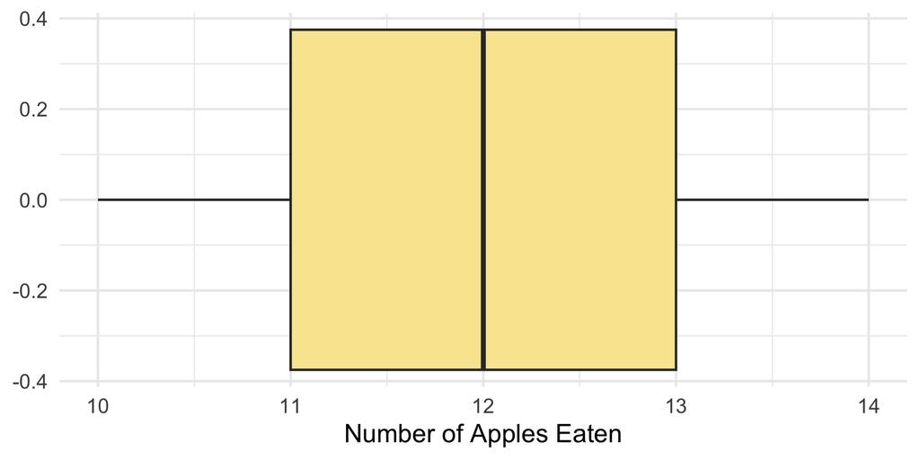

## Graphs: Box Plots

- Describe this box plot:

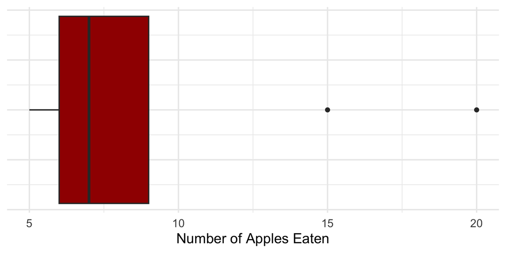

## Graphs: Box Plots

- Describe this box plot:

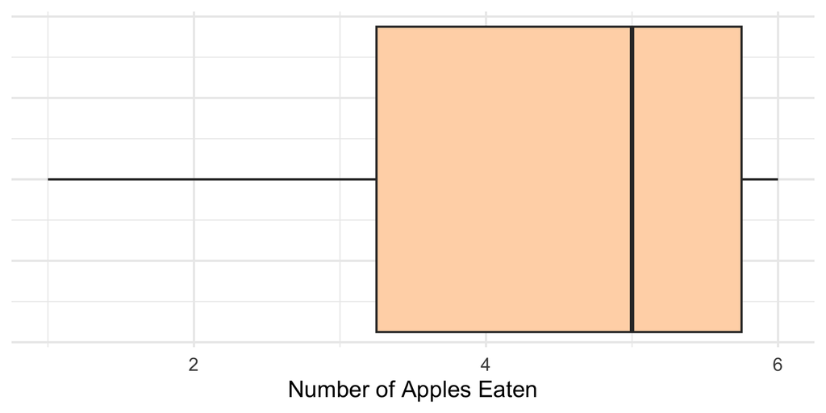

## Graphs: Box Plots

- Describe this box plot:

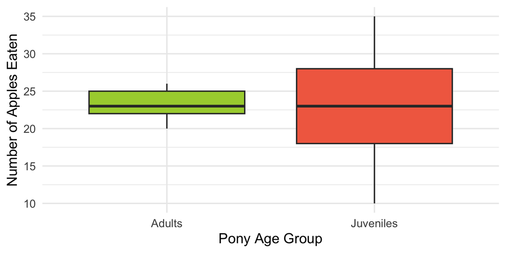

## Graphs: Histograms

- Histograms show the distribution (or *shape*) of a continuous variable.
- Values are grouped into intervals (“bins”), then the bin height demonstrates how many values fall into that interval.
- This allows us to quickly see if there are any oddities.
  - Increased proportion of a specific value/bin.
  - Any values that are “out in the tail”?

## Graphs: Histograms

- Describe the histogram:

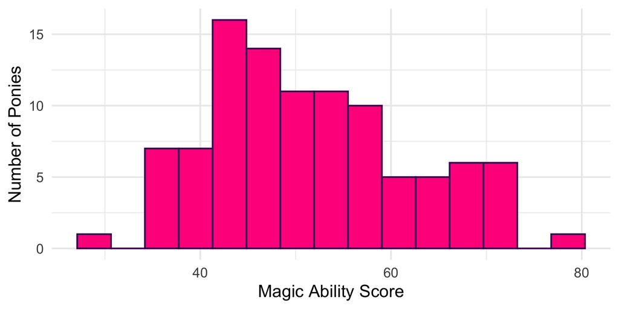

## Graphs: Histograms

- Describe the histogram:

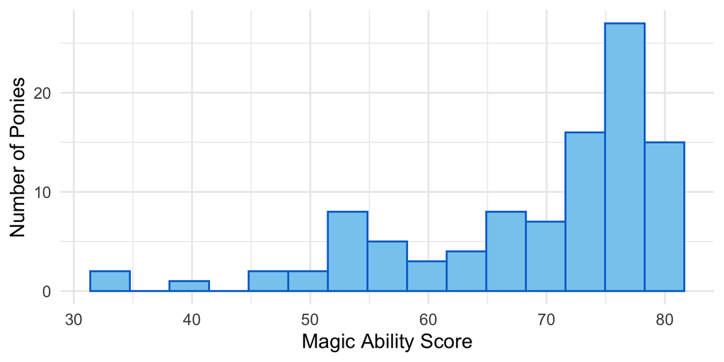

## Graphs: Histograms

- Describe the histogram:

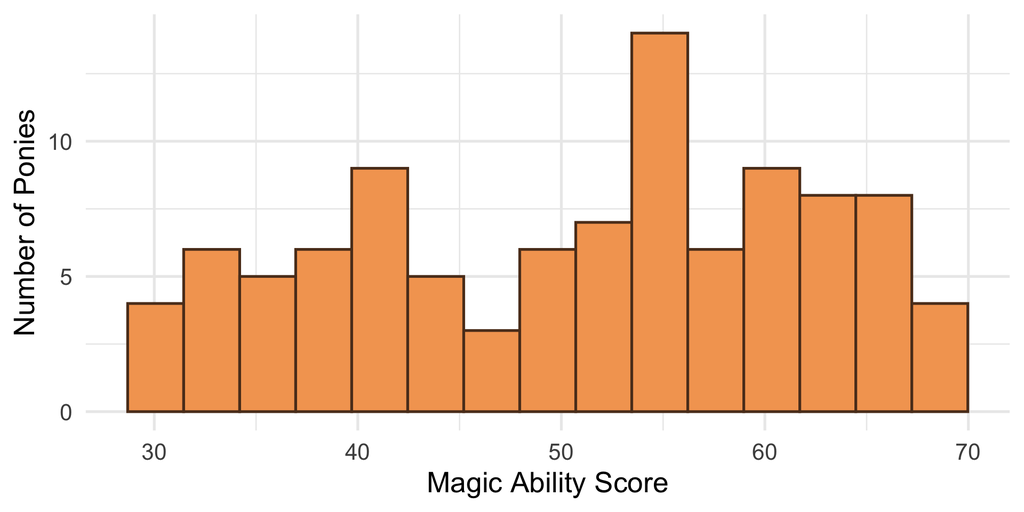

## Graphs: Histograms

- Describe the histogram:

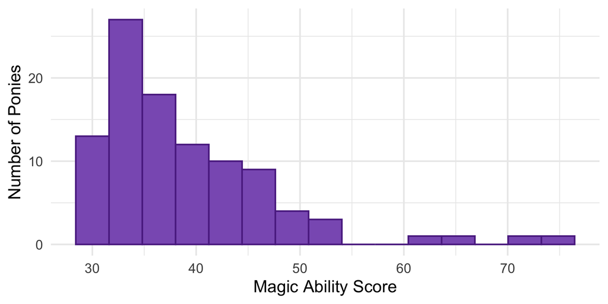

## Graphs: Histograms

- Describe the histogram:

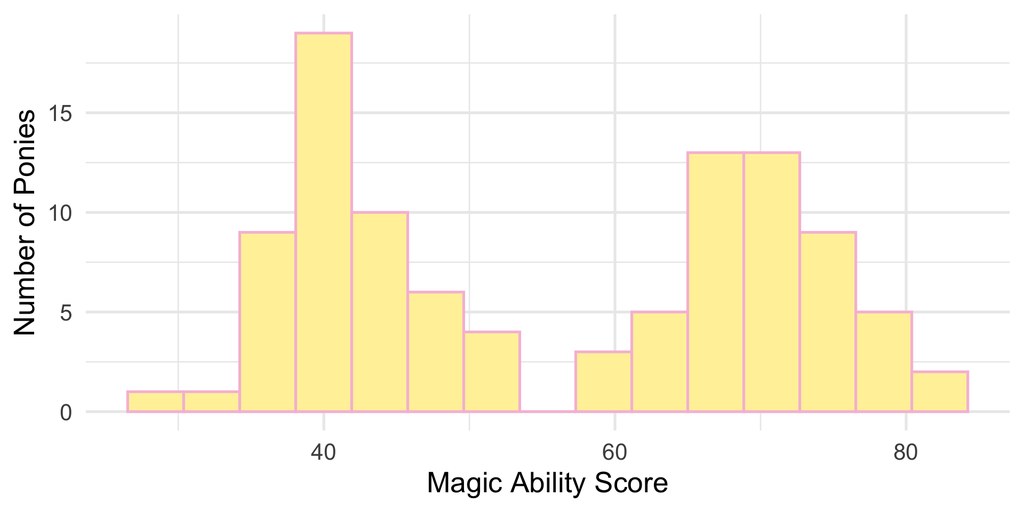

## Graphs: Bar Graphs

- Consider the bar graph, below.

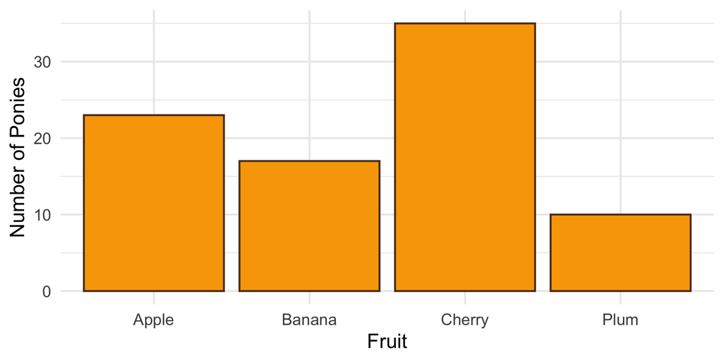

## Graphs: Side-by-Side Bar Graphs

- Consider the bar graph, below.

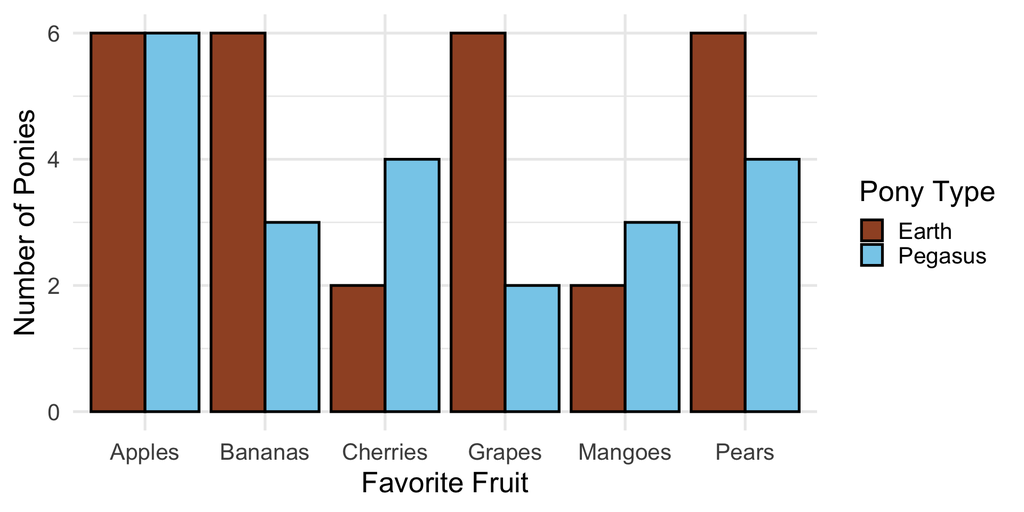

## Graphs: Stacked Bar Graphs

- Consider the bar graph, below.

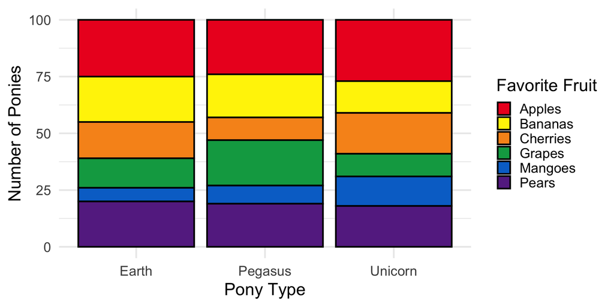

## Graphs: Histograms vs Bar Graphs

- We have now reviewed two “bar style” graphs that we see regularly: histograms and bar graphs.
- We use *histograms* to see the distribution of continuous variables.
  - The *x*-axis represents numeric intervals.
  - The bars touch each other to represent continuity.
- We use *bar graphs* to see the distribution of categorical variables.
  - The *x*-axis represents categories.
  - The bars do not touch each other, implying distinct categories.

## Graphs: Scatterplots

- Scatterplots allow us to look at the relationship between two continuous variables.
  - Each point on the graph represents one observation.
- What statisticians use scatterplots for:
  - Explore patterns (aka trends or relationships).
    - Linear relationships.
    - Non-linear relationships.
  - Detect clusters of observations.
  - Find oddities in the data (outliers).
- When we describe the relationship, we are really answering the question, “As *x* increases, what happens to *y*?”

## Graphs: Scatterplots

- Consider the scatterplot, below.

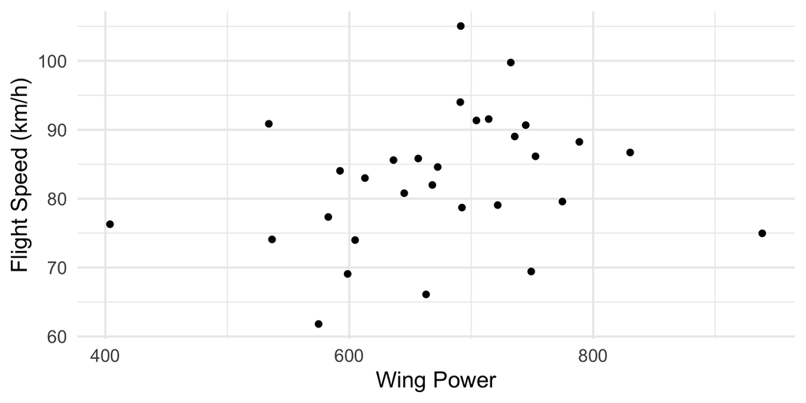

## Graphs: Scatterplots

- Consider the scatterplot, below.

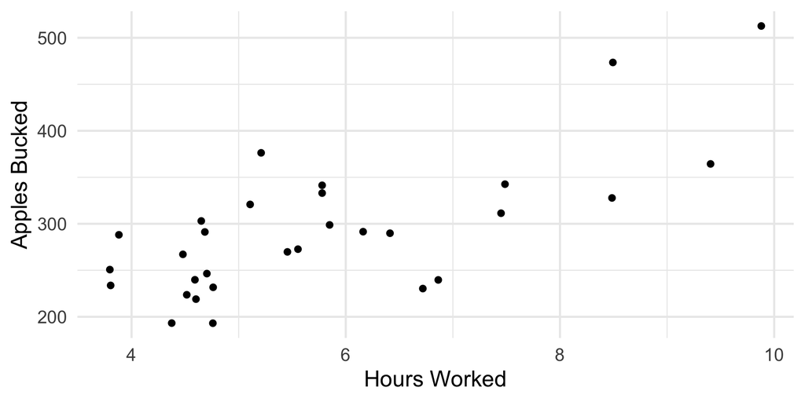

## Graphs: Scatterplots

- Consider the scatterplot, below.

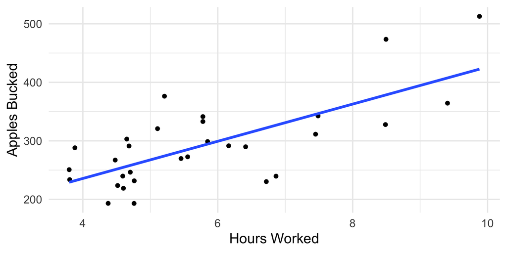

## Graphs: Scatterplots

- Consider the scatterplot, below.

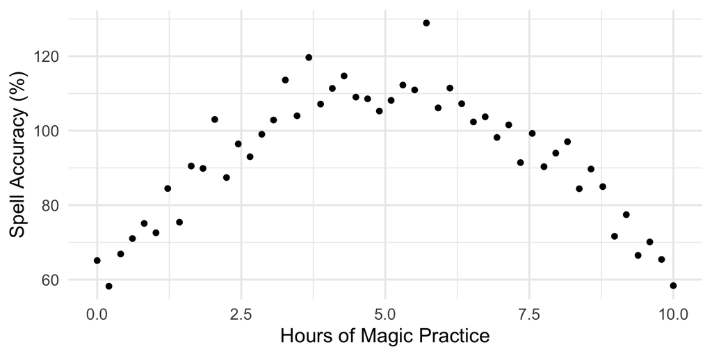

## Graphs: Scatterplots

- Consider the scatterplot, below.

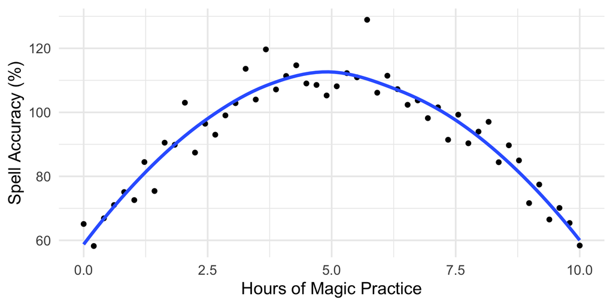

## Wrap Up

- We have covered (“reminded” ourselves of) a lot today!
  - Always remember that I do not expect you to:
    - Memorize code.
    - Produce code in a timed environment.
    - Automatically know how to do these things.
  - I do expect you to:
    - Use your resources (lecture slides, GitHub website).
    - Try your best.

## Wrap Up

- Today’s lecture:
  - Basic summarization of data.
  - Basic data visualization.
- Wednesday’s lecture:
  - Review of statistical inference.
    - Confidence intervals.
    - Hypothesis tests.